# Adult Metacarpal Length - Heritability estimate and GWAS Conditional Analysis

Caelinn James

02 April 2021

**Written for R 4.0.2, last updated 31/07/21**

This is a follow on from the adult metacarpal length heritability estimate and GWAS script. The analysis identified two peaks - one on chromosome 16 and one on chromosome 19. Here, we fit SNPs s74894.1 and s22142.1 to see how much of the variation they account for and to see if there are any close significant SNPs that are obscured by the original peaks.

### Load packages

```r
library(data.table)
library(stringr)
library(splitstackshape)
library(qqman)
```

### Preparing files

> #!/bin/sh  
> #$ -cwd  
> #$ -l h_rt=1:00:00  
> #$ -pe sharedmem 1  
> #$ -l h_vmem=100G  
> #$ -M s1944058@sms.ed.ac.uk  
> #$ -m baes

> . /etc/profile.d/modules.sh

> module load igmm/apps/plink/1.90b4 module load igmm/apps/R/3.5.1

> plink –bfile ../InputData/Plates_1to87_QC3 –sheep –not-chr 0,X –exclude-snps s74894.1, s22142.1 –make-bed –out 50K/Conditional_50K_Geno  
> plink –bfile ../InputData/sheep_geno_imputed_oar31_17052020 –sheep –not-chr X –exclude-snps s74894.1, s22142.1 –make-bed –out HD/Conditional_HD_Geno

> plink –bfile ../InputData/Plates_1to87_QC3 –sheep –snps s74894.1, s22142.1 –keep MetacarpalLength_AdultPhenotypes.txt –recodeA –out AdultMetaSNP cut -d ’ ’ -f 3-6 –complement AdultMetaSNP.raw > AdultMetaSNP.txt  
> sed ‘1d’ AdultMetaSNP.txt > AdultMetaSNP2.txt

> sort -k 2,2 MetacarpalLength_AdultQAssoc.txt > Assoc1.txt  
> sort -k 2,2 AdultMetaSNP2.txt > Assoc2.txt

> R  
> Assoc1 = read.table(“Assoc1.txt”)  
> Assoc2 = read.table(“Assoc2.txt”)  
> Assoc3 = merge(Assoc1,Assoc2,by=c(“V1”,“V2”)) write.table(Assoc3, “Assoc3.txt”,row.names=FALSE,col.names=FALSE,quote=FALSE) q()

> sort -k 2,2 MetacarpalLength_AdultAssoc.txt > Assoc.txt  
> sort -k 2,2 Assoc3.txt > QAssoc.txt

## Heritability Estimates

### 50K

> #!/bin/sh  
> #$ -cwd  
> #$ -l h_rt=1:00:00  
> #$ -pe sharedmem 1  
> #$ -l h_vmem=100G  
> #$ -M s1944058@sms.ed.ac.uk  
> #$ -m baes  
> . /etc/profile.d/modules.sh

> module load igmm/apps/dissect/1.15.2c  
> module load igmm/apps/plink/1.90b4

> mpirun -np 8 dissect.mpich --reml --bfile ../InputData/Plates_1to87_QC3 --pheno MetacarpalPhenotypes.txt --pheno-col 1 --blue --covar Assoc.txt --qcovar QAssoc.txt --random-effects MetacarpalRandom.txt --random-effects-cols 1 2 --out 50K/MetacarpalLength_Adult_50K_Conditional_H2

> if [[ -f 50K/MetacarpalLength_Adult_50K_Conditional_H2.badsnps ]]  
> then  
> plink --bfile ../InputData/Plates_1to87_QC3 --sheep --exclude 50K/MetacarpalLength_Adult_50K_Conditional_H2.badsnps --make-bed --out 50K/MetacarpalLength_Adult_50K_Conditional_H2

> mpirun -np 8 dissect.mpich --reml --bfile 50K/MetacarpalLength_Adult_50K_Conditional_H2 --pheno MetacarpalPhenotypes.txt --pheno-col 1 --blue --covar Assoc.txt --qcovar QAssoc.txt --random-effects MetacarpalRandom.txt --random-effects-cols 1 2 --out 50K/MetacarpalLength_Adult_50K_Conditional_H2  
> fi

```r
FixedEffects_50K
```

```
##               NAME      BETA       STD
## 1              Sex -2.969000 0.2566580
## 2     Age at death  0.140311 0.0424784
## 3 s74894.1 (Chr19) -3.515410 0.4453340
## 4 s22142.1 (Chr16) -2.239520 0.3266770
```

```r
RandomEffects_50K
```

```
##                            NAME     BETA       STD
## 1:                  Var(GRM_p1)   8.1208   1.01936
## 2:            Var(BirthYear_p1) 0.165009  0.127022
## 3:                    Var(E_p1)   5.4115  0.603949
## 4: Var(GRM_p1)/Var(Phenotype_1) 0.592876 0.0518236
```

### HD

> #!/bin/sh  
> #$ -cwd  
> #$ -l h_rt=1:00:00  
> #$ -pe sharedmem 1  
> #$ -l h_vmem=100G  
> #$ -M s1944058@sms.ed.ac.uk  
> #$ -m baes  
> . /etc/profile.d/modules.sh

> module load igmm/apps/dissect/1.15.2c  
> module load igmm/apps/plink/1.90b4

> mpirun -np 8 dissect.mpich --reml --bfile ../InputData/sheep_geno_imputed_oar31_17052020 --pheno MetacarpalPhenotypes.txt --pheno-col 1 --blue --covar Assoc.txt --qcovar QAssoc.txt --random-effects MetacarpalRandom.txt --random-effects-cols 1 2 --out HD/MetacarpalLength_Adult_HD_Conditional_H2

> if [[ -f HD/MetacarpalLength_Adult_HD_Conditional_H2.badsnps ]]  
> then  
> plink --bfile ../InputData/sheep_geno_imputed_oar31_17052020 --sheep --exclude HD/MetacarpalLength_Adult_HD_Conditional_H2.badsnps --make-bed --out HD/MetacarpalLength_Adult_HD_Conditional_H2

> mpirun -np 8 dissect.mpich --reml --bfile HD/MetacarpalLength_Adult_HD_Conditional_H2 --pheno MetacarpalPhenotypes.txt --pheno-col 1 --blue --covar Assoc.txt --qcovar QAssoc.txt --random-effects MetacarpalRandom.txt --random-effects-cols 1 2 --out HD/MetacarpalLength_Adult_HD_Conditional_H2  
> fi

```r
FixedEffects_HD
```

```
##               NAME      BETA      STD
## 1              Sex -2.956310 0.259115
## 2     Age at death  0.138916 0.042462
## 3 s74894.1 (Chr19) -3.519190 0.447566
## 4 s22142.1 (Chr16) -2.249250 0.327640
```

```r
RandomEffects_HD
```

```
##                            NAME     BETA       STD
## 1:                  Var(GRM_p1)  8.08613   1.01056
## 2:            Var(BirthYear_p1) 0.180573  0.132001
## 3:                    Var(E_p1)  5.35097   0.60269
## 4: Var(GRM_p1)/Var(Phenotype_1) 0.593797 0.0518326
```

### GWAS

> #!/bin/sh  
> #$ -cwd  
> #$ -l h_rt=2:00:00  
> #$ -pe sharedmem 1  
> #$ -l h_vmem=200G  
> #$ -t 1-26  
> #$ -tc 5  
> #$ -M s1944058@sms.ed.ac.uk  
> #$ -m baes  
> . /etc/profile.d/modules.sh

> module load igmm/apps/dissect/1.15.2c  
> module load igmm/apps/plink/1.90b4

> i=$_TASK_ID

> plink --bfile ../InputData/Plates_1to87_QC3 --sheep --not-chr ${i},X --keep MetacarpalPhenotypes.txt --make-bed --out 50K/NoChr${i}

> mpirun -np 8 dissect.mpich --make-grm --bfile 50K/NoChr${i} --out 50K/NoChr${i}_GRM

> echo "50K/Chr${i} 50K/NoChr${i}_GRM" > 50K/GWAS_GRM${i}.txt

> plink --bfile ../InputData/Plates_1to87_QC3 --sheep --chr ${i} --keep MetacarpalPhenotypes.txt --make-bed --out 50K/Chr${i}

> if [[ -f 50K/NoChr${i}_GRM.badsnps ]]  
> then  
> plink --bfile 50K/NoChr${i} --sheep --exclude 50K/NoChr${i}_GRM.badsnps --make-bed --out 50K/NoChr${i}_2

> mpirun -np 8 dissect.mpich --make-grm --bfile 50K/NoChr${i}_2 --out 50K/NoChr${i}_GRM

> fi

> mpirun -np 8 dissect.mpich --gwas --bfile-grm-list 50K/GWAS_GRM${i}.txt --pheno MetacarpalPhenotypes.txt --covar Assoc.txt --qcovar QAssoc.txt --random-effects MetacarpalRandom.txt --random-effects-cols 1,2 --out 50K/MetacarpalLength_Adult_50K_GWAS_Conditional_Chr${i}

> if [[ -f 50K/MetacarpalLength_Adult_50K_GWAS_Conditional_Chr${i}.badsnps ]]  
> then  
> plink --bfile 50K/Chr${i} --sheep --exclude 50K/MetacarpalLength_Adult_50K_GWAS_Conditional_Chr${i}.badsnps --make-bed --out 50K/Chr${i}_2

> echo "50K/Chr${i}_2 50K/NoChr${i}_GRM" > 50K/GWAS_GRM${i}.txt

> mpirun -np 8 dissect.mpich --gwas --bfile-grm-list 50K/GWAS_GRM${i}.txt --pheno MetacarpalPhenotypes.txt --covar Assoc.txt --qcovar QAssoc.txt --random-effects MetacarpalRandom.txt --random-effects-cols 1,2 --out 50K/MetacarpalLength_Adult_50K_GWAS_Conditional_Chr${i}  
> fi

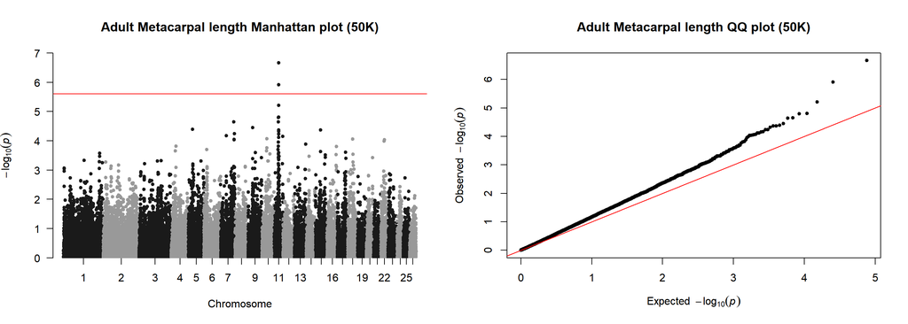

```r
files = list.files(pattern="MetacarpalLength_Adult_50K_GWAS_Conditional_Chr",recursive=TRUE)

SNPresults = do.call(rbind, lapply(files, function(x) read.table(x,header=T)))
SNPresults$Effect <- SNPresults$STDEV*SNPresults$STDEV*SNPresults$BETA*SNPresults$BETA

bimFile <- read.table("C:/Users/s1944058/Documents/Sheep/50KSNP/Plates_1to87_QC3.bim",header=F)

GWAS50KResults <- merge(bimFile,SNPresults[,c("SNP","PV","Effect"),],by.x="V2",by.y="SNP",all.x=FALSE,all.y=TRUE)
colnames(GWAS50KResults) <- c("SNP","Chr","V3","Pos","Ref","Minor","PV","Effect")
GWAS50KResults$Chr <- as.numeric(GWAS50KResults$Chr)
par(mfrow=c(1,2))
manhattan(GWAS50KResults,chr="Chr",bp="Pos",p="PV",snp="SNP", main = "Adult Metacarpal length Manhattan plot (50K)", genomewideline = -log10(0.05/20082),suggestiveline = FALSE)
qq(GWAS50KResults$PV,main="Adult Metacarpal length QQ plot (50K)")
```

```r
SNPs <- GWAS50KResults[which(GWAS50KResults$PV < (0.05/20082) ),c("Chr","Pos","SNP","PV","Effect")]
SNPs[order(SNPs$PV),]
```

```
##      Chr      Pos              SNP         PV    Effect
## 4762  11 31280002 OAR11_33324109.1 2.1708e-07 0.2152774
## 4765  11 31380176 OAR11_33427461.1 1.2291e-06 0.1818835
```

### Imputed SNP data

> #!/bin/sh  
> #$ -cwd  
> #$ -l h_rt=3:00:00  
> #$ -pe sharedmem 1  
> #$ -l h_vmem=200G  
> #$ -t 1-26  
> #$ -tc 5  
> #$ -M s1944058@sms.ed.ac.uk  
> #$ -m baes  
> . /etc/profile.d/modules.sh

> module load igmm/apps/dissect/1.15.2c  
> module load igmm/apps/plink/1.90b4

> i=$_TASK_ID

> plink --bfile ../InputData/sheep_geno_imputed_oar31_17052020 --sheep --not-chr ${i},X --keep MetacarpalPhenotypes.txt --make-bed --out HD/NoChr${i}

> mpirun -np 8 dissect.mpich --make-grm --bfile HD/NoChr${i} --out HD/NoChr${i}_GRM

> echo "HD/Chr${i} HD/NoChr${i}_GRM" > HD/GWAS_GRM${i}.txt

> plink --bfile ../InputData/sheep_geno_imputed_oar31_17052020 --sheep --chr ${i} --keep MetacarpalPhenotypes.txt --make-bed --out HD/Chr${i}

> if [[ -f HD/NoChr${i}_GRM.badsnps ]]  
> then  
> plink --bfile HD/NoChr${i} --sheep --exclude HD/NoChr${i}_GRM.badsnps --make-bed --out HD/NoChr${i}_2

> mpirun -np 8 dissect.mpich --make-grm --bfile HD/NoChr${i}_2 --out HD/NoChr${i}_GRM

> fi

> mpirun -np 8 dissect.mpich --gwas --bfile-grm-list HD/GWAS_GRM${i}.txt --pheno MetacarpalPhenotypes.txt --covar Assoc.txt --qcovar QAssoc.txt --random-effects MetacarpalRandom.txt --random-effects-cols 1,2 --out HD/MetacarpalLength_Adult_HD_GWAS_Conditional_Chr${i}

> if [[ -f HD/MetacarpalLength_Adult_HD_GWAS_Conditional_Chr${i}.badsnps ]]  
> then  
> plink --bfile HD/Chr${i} --sheep --exclude HD/MetacarpalLength_Adult_HD_GWAS_Conditional_Chr${i}.badsnps --make-bed --out HD/Chr${i}_2

> echo "HD/Chr${i}_2 HD/NoChr${i}_GRM" > HD/GWAS_GRM${i}.txt

> mpirun -np 8 dissect.mpich --gwas --bfile-grm-list HD/GWAS_GRM${i}.txt --pheno MetacarpalPhenotypes.txt --covar Assoc.txt --qcovar QAssoc.txt --random-effects MetacarpalRandom.txt --random-effects-cols 1,2 --out HD/MetacarpalLength_Adult_HD_GWAS_Conditional_Chr${i}  
> fi

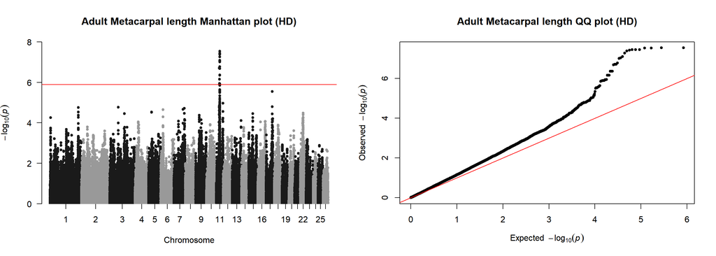

```r
files = list.files(pattern="MetacarpalLength_Adult_HD_GWAS_Conditional_Chr",recursive=TRUE)

SNPresults = do.call(rbind, lapply(files, function(x) read.table(x,header=T)))
SNPresults$Effect <- SNPresults$STDEV*SNPresults$STDEV*SNPresults$BETA*SNPresults$BETA

bimFile <- read.table("C:/Users/s1944058/Documents/Sheep/HDSNP/sheep_geno_imputed_oar31_17052020.bim",header=F)

GWASHDResults <- merge(bimFile,SNPresults[,c("SNP","PV","Effect"),],by.x="V2",by.y="SNP",all.x=FALSE,all.y=TRUE)
colnames(GWASHDResults) <- c("SNP","Chr","V3","Pos","Ref","Minor","PV","Effect")
GWASHDResults$Chr <- as.numeric(GWASHDResults$Chr)
par(mfrow=c(1,2))
manhattan(GWASHDResults,chr="Chr",bp="Pos",p="PV",snp="SNP", main = "Adult Metacarpal length Manhattan plot (HD)", genomewideline = -log10(0.05/39149),suggestiveline = FALSE)
qq(GWASHDResults$PV,main="Adult Metacarpal length QQ plot (HD)")
```

```r
SNPs <- GWASHDResults[which(GWASHDResults$PV < (0.05/39149) ),c("Chr","Pos","SNP","PV","Effect")]
SNPs[order(SNPs$PV),]
```

```
##       Chr      Pos                 SNP         PV    Effect
## 80015  11 31212644 oar3_OAR11_31212644 2.9333e-08 0.2442267
## 80016  11 31226074 oar3_OAR11_31226074 2.9333e-08 0.2442267
## 80017  11 31243710 oar3_OAR11_31243710 2.9434e-08 0.2442267
## 80018  11 31244373 oar3_OAR11_31244373 2.9434e-08 0.2442267
## 80005  11 31157086 oar3_OAR11_31157086 3.6039e-08 0.2386684
## 80006  11 31168631 oar3_OAR11_31168631 3.6039e-08 0.2386684
## 80008  11 31169920 oar3_OAR11_31169920 3.6039e-08 0.2386684
## 80012  11 31204744 oar3_OAR11_31204744 3.8388e-08 0.2400520
## 80023  11 31268214 oar3_OAR11_31268214 4.2250e-08 0.2386684
## 80091  11 31585006 oar3_OAR11_31585006 5.4247e-08 0.2211210
## 80085  11 31559828 oar3_OAR11_31559828 8.0754e-08 0.2165041
## 80099  11 31623748 oar3_OAR11_31623748 9.2696e-08 0.2138878
## 80048  11 31381900 oar3_OAR11_31381900 9.8123e-08 0.2204941
## 80007  11 31168975 oar3_OAR11_31168975 1.6875e-07 0.2158048
## 79188  11 26436648 oar3_OAR11_26436648 1.9404e-07 0.2125376
## 79189  11 26446844 oar3_OAR11_26446844 1.9404e-07 0.2125376
## 80054  11 31415567 oar3_OAR11_31415567 2.1131e-07 0.2012222
## 4926   11 31280002    OAR11_33324109.1 4.3664e-07 0.2043302
## 80100  11 31641330 oar3_OAR11_31641330 4.4066e-07 0.1882137
## 80101  11 31641507 oar3_OAR11_31641507 4.4066e-07 0.1882137
## 79782  11 29896204 oar3_OAR11_29896204 6.9216e-07 0.1540531
## 79794  11 29987623 oar3_OAR11_29987623 7.0429e-07 0.1540531
## 79795  11 29995815 oar3_OAR11_29995815 7.0429e-07 0.1540531
## 79780  11 29893020 oar3_OAR11_29893020 1.1256e-06 0.1482358
## 79983  11 30993447 oar3_OAR11_30993447 1.1855e-06 0.1789036
## 79985  11 31003550 oar3_OAR11_31003550 1.1855e-06 0.1789036
## 79778  11 29881030 oar3_OAR11_29881030 1.2742e-06 0.1468001
## 79779  11 29884883 oar3_OAR11_29884883 1.2742e-06 0.1468001
```

## **FINAL RESULTS**

### 50K

```r
FixedEffects_50K[c(3,4),]
```

```
##               NAME     BETA      STD
## 3 s74894.1 (Chr19) -3.51541 0.445334
## 4 s22142.1 (Chr16) -2.23952 0.326677
```

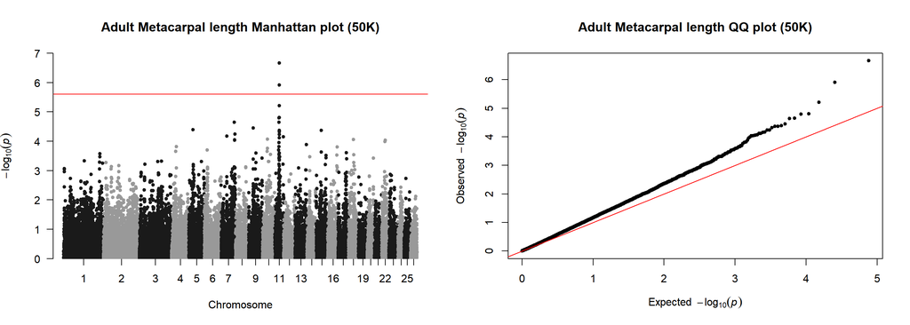

```r
par(mfrow=c(1,2))
manhattan(GWAS50KResults,chr="Chr",bp="Pos",p="PV",snp="SNP", main = "Adult Metacarpal length Manhattan plot (50K)", genomewideline = -log10(0.05/20082),suggestiveline = FALSE)
qq(GWAS50KResults$PV,main="Adult Metacarpal length QQ plot (50K)")
```

### HD

```r
FixedEffects_HD[c(3,4),]
```

```
##               NAME     BETA      STD
## 3 s74894.1 (Chr19) -3.51919 0.447566
## 4 s22142.1 (Chr16) -2.24925 0.327640
```

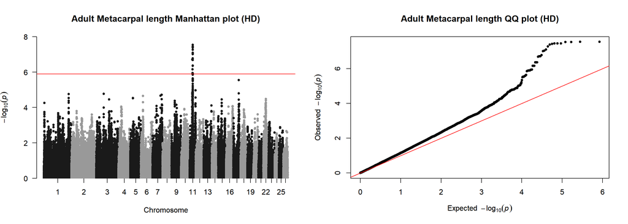

```r
par(mfrow=c(1,2))
manhattan(GWASHDResults,chr="Chr",bp="Pos",p="PV",snp="SNP", main = "Adult Metacarpal length Manhattan plot (HD)", genomewideline = -log10(0.05/39149),suggestiveline = FALSE)
qq(GWASHDResults$PV,main="Adult Metacarpal length QQ plot (HD)")
```